# Amazon Product Reviews

```python
import pandas as pd
import numpy as np
import matplotlib.pyplot as plt
```

```python
data=pd.read_csv("Reviews.csv")
data
```

|  | Id | ProductId | UserId | ProfileName | HelpfulnessNumerator | HelpfulnessDenominator | Score | Time | Summary | Text |
| --- | --- | --- | --- | --- | --- | --- | --- | --- | --- | --- |
| 0 | 1 | B001E4KFG0 | A3SGXH7AUHU8GW | delmartian | 1 | 1 | 5 | 1303862400 | Good Quality Dog Food | I have bought several of the Vitality canned d... |
| 1 | 2 | B00813GRG4 | A1D87F6ZCVE5NK | dll pa | 0 | 0 | 1 | 1346976000 | Not as Advertised | Product arrived labeled as Jumbo Salted Peanut... |
| 2 | 3 | B000LQOCH0 | ABXLMWJIXXAIN | Natalia Corres "Natalia Corres" | 1 | 1 | 4 | 1219017600 | "Delight" says it all | This is a confection that has been around a fe... |
| 3 | 4 | B000UA0QIQ | A395BORC6FGVXV | Karl | 3 | 3 | 2 | 1307923200 | Cough Medicine | If you are looking for the secret ingredient i... |
| 4 | 5 | B006K2ZZ7K | A1UQRSCLF8GW1T | Michael D. Bigham "M. Wassir" | 0 | 0 | 5 | 1350777600 | Great taffy | Great taffy at a great price. There was a wid... |
| ... | ... | ... | ... | ... | ... | ... | ... | ... | ... | ... |
| 568449 | 568450 | B001EO7N10 | A28KG5XORO54AY | Lettie D. Carter | 0 | 0 | 5 | 1299628800 | Will not do without | Great for sesame chicken..this is a good if no... |
| 568450 | 568451 | B003S1WTCU | A3I8AFVPEE8KI5 | R. Sawyer | 0 | 0 | 2 | 1331251200 | disappointed | I'm disappointed with the flavor. The chocolat... |
| 568451 | 568452 | B004I613EE | A121AA1GQV751Z | pksd "pk_007" | 2 | 2 | 5 | 1329782400 | Perfect for our maltipoo | These stars are small, so you can give 10-15 o... |
| 568452 | 568453 | B004I613EE | A3IBEVCTXKNOH | Kathy A. Welch "katwel" | 1 | 1 | 5 | 1331596800 | Favorite Training and reward treat | These are the BEST treats for training and rew... |
| 568453 | 568454 | B001LR2CU2 | A3LGQPJCZVL9UC | srfell17 | 0 | 0 | 5 | 1338422400 | Great Honey | I am very satisfied ,product is as advertised,... |

568454 rows × 10 columns

- 데이터가 568454개이기 때문에 일부분만 추출해서 분석 예정

```python
data_set = data[25000:50000]
data_set.info()
```

```
<class 'pandas.core.frame.DataFrame'>
RangeIndex: 25000 entries, 25000 to 49999
Data columns (total 10 columns):
 #   Column                  Non-Null Count  Dtype
---  ------                  --------------  -----
 0   Id                      25000 non-null  int64
 1   ProductId               25000 non-null  object
 2   UserId                  25000 non-null  object
 3   ProfileName             24997 non-null  object
 4   HelpfulnessNumerator    25000 non-null  int64
 5   HelpfulnessDenominator  25000 non-null  int64
 6   Score                   25000 non-null  int64
 7   Time                    25000 non-null  int64
 8   Summary                 24998 non-null  object
 9   Text                    25000 non-null  object
dtypes: int64(5), object(5)
memory usage: 1.9+ MB
```

```python
data_set.head()
```

|  | Id | ProductId | UserId | ProfileName | HelpfulnessNumerator | HelpfulnessDenominator | Score | Time | Summary | Text |
| --- | --- | --- | --- | --- | --- | --- | --- | --- | --- | --- |
| 25000 | 25001 | B0078Y6OX8 | A3P0TJ7GYKM9L9 | Elena Mann Bowman "elenasstar" | 1 | 1 | 5 | 1284681600 | Delicious coffee | Van Houtte is my favorite K cups brand. I am r... |
| 25001 | 25002 | B0078Y6OX8 | A3THT6EZQFPY7P | gumgirl | 1 | 1 | 5 | 1283904000 | Love this Flavor | I just ordered and received this flavor of K-c... |
| 25002 | 25003 | B0078Y6OX8 | A2BUSR3U0RVFAM | Bett E Crocker | 1 | 1 | 4 | 1282953600 | Chocolate Raspberry Truffle K-Cup | How can anyone go wrong with Chocolate Raspber... |
| 25003 | 25004 | B0078Y6OX8 | A2Z4TQN4C4WSSB | Kelly L. Roth | 1 | 1 | 5 | 1282348800 | Wonderful flavor | This is a great smooth flavorful cup of coffee... |
| 25004 | 25005 | B0078Y6OX8 | A2Z4TQN4C4WSSB | Kelly L. Roth | 1 | 1 | 5 | 1282348800 | Yummy Flavor | This coffee is a great yummy flavor and a favo... |

- 체크할 부분
  - UserID가 중복되는 row가 있는지 확인
  - 같은 사람이 여러 아이디를 만들 수 있음 -> UserID가 같고 ProfileName이 다를 수 있음

## 1. 데이터 전처리 계획

```python
# 리뷰의 유익성 판단 요소 (보류)
# 리뷰에 대한 좋아요 수
data_set["HelpfulnessNumerator"].value_counts()
```

```
0      13313
1       5216
2       2387
3       1242
4        749
       ...
72         1
56         1
133        1
149        1
95         1
Name: HelpfulnessNumerator, Length: 83, dtype: int64
```

```python
# 리뷰의 유익성 판단 요소 (보류)
# 리뷰에 대한 관심
# 관심에 대한 좋아요 수의 비율 파악 후 전처리
data_set["HelpfulnessDenominator"].value_counts()
```

```
0      11921
1       4938
2       2700
3       1503
4        992
       ...
85         1
37         1
124        1
212        1
188        1
Name: HelpfulnessDenominator, Length: 84, dtype: int64
```

```python
data_set["ProfileName"].value_counts()
#실제이름인가? -> work shopper, Amzn shopper 등등 "" 안의 내용들이 무엇일까?
#아마 닉네임인 것 같음
```

```
Gary Peterson                             26
O. Brown "Ms. O. Khannah-Brown"           22
C. F. Hill "CFH"                          21
Gunner                                    20
Rebecca of Amazon "The Rebecca Review"    19
                                          ..
E. Garrett "EG"                            1
Tiger                                      1
Susan K. Fox "sfox750"                     1
Healthy Living                             1
Jingletown                                 1
Name: ProfileName, Length: 20552, dtype: int64
```

```python
data_set["UserId"].value_counts()
#ProfileName과 UserId가 완전히 같은지 확인할 예정
```

```
AY12DBB0U420B     26
A1YUL9PCJR3JTY    22
A3OXHLG6DIBRW8    21
A1TMAVN4CEM8U8    20
A281NPSIMI1C2R    19
                  ..
A2OBX3W148CSWM     1
A15QK71NQ22C2W     1
A81O63DZ3KG19      1
A3QB2K436BOIIM     1
A7GV4W4FH7CPY      1
Name: UserId, Length: 21841, dtype: int64
```

```python
data_set["Summary"].value_counts()
#비슷한 단어에 대해서 공통적으로 통일할 필요가 있음
```

```
Delicious!                             113
Delicious                              102
Yummy!                                  70
Yummy                                   62
Yum!                                    57
                                      ...
Jerky Jerky                              1
Much weaker blend than the original      1
Owner, historic Inn & B&B                1
Great way to shop!                       1
Put it on top of sliced apples.          1
Name: Summary, Length: 20606, dtype: int64
```

```python
data_set["Time"].value_counts()
```

```
1343174400    80
1337731200    63
1343606400    60
1298505600    60
1344211200    57
              ..
1165881600     1
1153440000     1
1207872000     1
1185840000     1
1075075200     1
Name: Time, Length: 2302, dtype: int64
```

## 2. 데이터 분석 계획

- 물건 평점 분석
  - 전체적인 물건에 대한 평점 분포는 어떠한가
  - 각 물건에 대한 평점 분포 파악 (평점이 높은 물건과 낮은 물건 확인)
  - User에 따른 평점 분포 파악 (분포의 정규화)
  - 어떤 종류의 물건이 많은 리뷰를 가지고 있는가
- 리뷰 분석
  - 리뷰의 긍정성과 부정성 판단하는 점수 내기
  - 리뷰에 대한 유용성 판단하고 유용성과 리뷰 별점의 상관관계 파악하기 -긍정성과 부정성 판단하는 점수와 리뷰별점의 상관관계 파악하기

## 3. 데이터 전처리

```python
# 중복값 찾기
a=data_set.loc[:,["UserId","ProfileName"]]
```

```python
# UserId와 ProfileName이 같은 값을 가짐 (ProfileName column 삭제)
aa=a["UserId"]=='A1YUL9PCJR3JTY'
a[aa]
```

|  | UserId | ProfileName |
| --- | --- | --- |
| 26996 | A1YUL9PCJR3JTY | O. Brown "Ms. O. Khannah-Brown" |
| 29081 | A1YUL9PCJR3JTY | O. Brown "Ms. O. Khannah-Brown" |
| 32241 | A1YUL9PCJR3JTY | O. Brown "Ms. O. Khannah-Brown" |
| 34793 | A1YUL9PCJR3JTY | O. Brown "Ms. O. Khannah-Brown" |
| 34809 | A1YUL9PCJR3JTY | O. Brown "Ms. O. Khannah-Brown" |
| 34888 | A1YUL9PCJR3JTY | O. Brown "Ms. O. Khannah-Brown" |
| 34889 | A1YUL9PCJR3JTY | O. Brown "Ms. O. Khannah-Brown" |
| 37313 | A1YUL9PCJR3JTY | O. Brown "Ms. O. Khannah-Brown" |
| 37319 | A1YUL9PCJR3JTY | O. Brown "Ms. O. Khannah-Brown" |
| 38133 | A1YUL9PCJR3JTY | O. Brown "Ms. O. Khannah-Brown" |
| 39873 | A1YUL9PCJR3JTY | O. Brown "Ms. O. Khannah-Brown" |
| 41033 | A1YUL9PCJR3JTY | O. Brown "Ms. O. Khannah-Brown" |
| 41764 | A1YUL9PCJR3JTY | O. Brown "Ms. O. Khannah-Brown" |
| 43035 | A1YUL9PCJR3JTY | O. Brown "Ms. O. Khannah-Brown" |
| 43036 | A1YUL9PCJR3JTY | O. Brown "Ms. O. Khannah-Brown" |
| 45137 | A1YUL9PCJR3JTY | O. Brown "Ms. O. Khannah-Brown" |
| 46054 | A1YUL9PCJR3JTY | O. Brown "Ms. O. Khannah-Brown" |
| 46070 | A1YUL9PCJR3JTY | O. Brown "Ms. O. Khannah-Brown" |
| 46869 | A1YUL9PCJR3JTY | O. Brown "Ms. O. Khannah-Brown" |
| 49521 | A1YUL9PCJR3JTY | O. Brown "Ms. O. Khannah-Brown" |
| 49537 | A1YUL9PCJR3JTY | O. Brown "Ms. O. Khannah-Brown" |
| 49805 | A1YUL9PCJR3JTY | O. Brown "Ms. O. Khannah-Brown" |

```python
data_set=data_set.drop("ProfileName",axis=1)
data_set
```

|  | Id | ProductId | UserId | HelpfulnessNumerator | HelpfulnessDenominator | Score | Time | Summary | Text |
| --- | --- | --- | --- | --- | --- | --- | --- | --- | --- |
| 25000 | 25001 | B0078Y6OX8 | A3P0TJ7GYKM9L9 | 1 | 1 | 5 | 1284681600 | Delicious coffee | Van Houtte is my favorite K cups brand. I am r... |
| 25001 | 25002 | B0078Y6OX8 | A3THT6EZQFPY7P | 1 | 1 | 5 | 1283904000 | Love this Flavor | I just ordered and received this flavor of K-c... |
| 25002 | 25003 | B0078Y6OX8 | A2BUSR3U0RVFAM | 1 | 1 | 4 | 1282953600 | Chocolate Raspberry Truffle K-Cup | How can anyone go wrong with Chocolate Raspber... |
| 25003 | 25004 | B0078Y6OX8 | A2Z4TQN4C4WSSB | 1 | 1 | 5 | 1282348800 | Wonderful flavor | This is a great smooth flavorful cup of coffee... |
| 25004 | 25005 | B0078Y6OX8 | A2Z4TQN4C4WSSB | 1 | 1 | 5 | 1282348800 | Yummy Flavor | This coffee is a great yummy flavor and a favo... |
| ... | ... | ... | ... | ... | ... | ... | ... | ... | ... |
| 49995 | 49996 | B00430B73W | AKW867T7C6HF8 | 0 | 0 | 5 | 1261180800 | Grown to really like them | My sister introduced me to these. They have be... |
| 49996 | 49997 | B00430B73W | A2PEHNEDMHOYTW | 0 | 0 | 5 | 1258934400 | Healthy Snack at a great price! | A friend recommended these bars and I fell in ... |
| 49997 | 49998 | B00430B73W | A2QH2KF2IAB143 | 0 | 0 | 5 | 1257379200 | Raw Revolution Hazelnut Cashew | Fabulous! I take one to work with me every da... |
| 49998 | 49999 | B00430B73W | AMX286UGXISMA | 0 | 0 | 4 | 1247702400 | fantastic, but chew carefully | I love these bars and will continue to buy the... |
| 49999 | 50000 | B00430B73W | A3042WJDYJ22S8 | 0 | 0 | 5 | 1178755200 | Very Tasty and Healthy. | These are very good; nutritious, great flavor ... |

25000 rows × 9 columns

```python
#리뷰 유용성 파악하는 컬럼 만들기
#HelpfulnessNumerator와 HelpfulnessDenominator로 새로운 column 생성
b=data_set.loc[:,["HelpfulnessNumerator","HelpfulnessDenominator"]]
b
```

|  | HelpfulnessNumerator | HelpfulnessDenominator |
| --- | --- | --- |
| 25000 | 1 | 1 |
| 25001 | 1 | 1 |
| 25002 | 1 | 1 |
| 25003 | 1 | 1 |
| 25004 | 1 | 1 |
| ... | ... | ... |
| 49995 | 0 | 0 |
| 49996 | 0 | 0 |
| 49997 | 0 | 0 |
| 49998 | 0 | 0 |
| 49999 | 0 | 0 |

25000 rows × 2 columns

```python
bb=b["HelpfulnessNumerator"]==0
b[bb]
```

|  | HelpfulnessNumerator | HelpfulnessDenominator |
| --- | --- | --- |
| 25021 | 0 | 0 |
| 25022 | 0 | 0 |
| 25023 | 0 | 0 |
| 25024 | 0 | 0 |
| 25025 | 0 | 0 |
| ... | ... | ... |
| 49995 | 0 | 0 |
| 49996 | 0 | 0 |
| 49997 | 0 | 0 |
| 49998 | 0 | 0 |
| 49999 | 0 | 0 |

13313 rows × 2 columns

```python
#Helpfulness: 리뷰의 유용성 지수- 이 제품이 유익한지...
data_set["Helpfulness"]=data_set["HelpfulnessNumerator"]/data_set["HelpfulnessDenominator"]
```

```python
# Denominator는 분모가 0이 되기 때문에 na 존재, na값은 0으로 대체
data_set["Helpfulness"].fillna(0)
```

```
25000    1.0
25001    1.0
25002    1.0
25003    1.0
25004    1.0
        ...
49995    0.0
49996    0.0
49997    0.0
49998    0.0
49999    0.0
Name: Helpfulness, Length: 25000, dtype: float64
```

```python
data_set["Helpfulness"].value_counts()
```

```
1.000000    8009
0.000000    1392
0.500000     995
0.666667     498
0.750000     306
            ...
0.926316       1
0.976744       1
0.972603       1
0.957547       1
0.982906       1
Name: Helpfulness, Length: 229, dtype: int64
```

```python
c=data_set.loc[:,["Score"]]
c
```

|  | Score |
| --- | --- |
| 25000 | 5 |
| 25001 | 5 |
| 25002 | 4 |
| 25003 | 5 |
| 25004 | 5 |
| ... | ... |
| 49995 | 5 |
| 49996 | 5 |
| 49997 | 5 |
| 49998 | 4 |
| 49999 | 5 |

25000 rows × 1 columns

```python
!pip install wordcloud
```

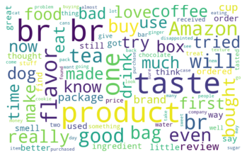

```python
# wordcloud를 통한 단어 시각화
from sklearn.feature_extraction.text import CountVectorizer
from sklearn.feature_extraction.text import TfidfVectorizer
from collections import Counter
from wordcloud import WordCloud

txt = ' '.join(review for review in bad_score.Text)

wordcloud = WordCloud(
            background_color = 'white',
            max_font_size = 100,
            max_words = 100,
            width = 800,
            height = 500
            ).generate(txt)


plt.imshow(wordcloud,interpolation = 'bilinear')
plt.axis('off')
plt.show()
```

```python
!pip install nltk
```

```python
import nltk
nltk.download()
```

```
showing info https://raw.githubusercontent.com/nltk/nltk_data/gh-pages/index.xml
```

```
True
```

```python
# 비슷한 단어 처리-자연어처리(필요없는 부분 삭제)
data_set["Summary"] = data_set["Summary"].apply(lambda x: x.lower() if x.__class__ == "".__class__ else "")

from nltk.corpus import stopwords

http_stopwords = ["br", "http", "https", "span"]

STOPWORDS = http_stopwords + list(stopwords.words("english")) + ['i', 'me', 'my', 'myself', 'we', 'our', 'ours', 'ourselves', 'you', "you're", "you've",\
            "you'll", "you'd", 'your', 'yours', 'yourself', 'yourselves', 'he', 'him', 'his', 'himself', \
            'she', "she's", 'her', 'hers', 'herself', 'it', "it's", 'its', 'itself', 'they', 'them', 'their',\
            'theirs', 'themselves', 'what', 'which', 'who', 'whom', 'this', 'that', "that'll", 'these', 'those', \
            'am', 'is', 'are', 'was', 'were', 'be', 'been', 'being', 'have', 'has', 'had', 'having', 'do', 'does', \
            'did', 'doing', 'a', 'an', 'the', 'and', 'but', 'if', 'or', 'because', 'as', 'until', 'while', 'of', \
            'at', 'by', 'for', 'with', 'about', 'against', 'between', 'into', 'through', 'during', 'before', 'after',\
                                                                             'above', 'below', 'to', 'from', 'up', 'down', 'in', 'out', 'on', 'off', 'over', 'under', 'again', 'further',\
            'then', 'once', 'here', 'there', 'when', 'where', 'why', 'how', 'all', 'any', 'both', 'each', 'few', 'more',\
            'most', 'other', 'some', 'such', 'only', 'own', 'same', 'so', 'than', 'too', 'very', \
            's', 't', 'can', 'will', 'just', 'don', "don't", 'should', "should've", 'now', 'd', 'll', 'm', 'o', 're', \
            've', 'y', 'ain', 'aren', "aren't", 'couldn', "couldn't", 'didn', "didn't", 'doesn', "doesn't", 'hadn',\
            "hadn't", 'hasn', "hasn't", "haven't", 'isn', "isn't", 'ma', 'mightn', "mightn't", 'mustn',\
            "mustn't", 'needn', "needn't", 'shan', "shan't", 'shouldn', "shouldn't", 'wasn', "wasn't", 'weren', "weren't", \
            'won', "won't", 'wouldn', "wouldn't"]

STOPWORDS = set(STOPWORDS)


import re

def decontract_and_clean(phrase):
    # specific
    phrase = re.sub("[^a-zA-Z]",  " ", str(phrase))
    phrase = re.sub(r"won't", "will not", phrase)
    phrase = re.sub(r"can\'t", "can not", phrase)

    # general
    phrase = re.sub(r"n\'t", " not", phrase)
    phrase = re.sub(r"\'re", " are", phrase)
    phrase = re.sub(r"\'s", " is", phrase)
    phrase = re.sub(r"\'d", " would", phrase)
    phrase = re.sub(r"\'ll", " will", phrase)
    phrase = re.sub(r"\'t", " not", phrase)
    phrase = re.sub(r"\'ve", " have", phrase)
    phrase = re.sub(r"\'m", " am", phrase)
    phrase = phrase.replace('\\r', ' ')
    phrase = phrase.replace('\\"', ' ')
    phrase = phrase.replace('\\n', ' ')
    phrase = re.sub('[^A-Za-z0-9]+', ' ', phrase)
    # https://gist.github.com/sebleier/554280
    phrase = ' '.join(e for e in phrase.split() if e.lower() not in STOPWORDS)
    return phrase
data_set["Summary"] = data_set["Summary"].apply(decontract_and_clean)

from nltk.stem import WordNetLemmatizer

lemmatizer = WordNetLemmatizer()

data_set["Summary"] = data_set["Summary"].apply(lemmatizer.lemmatize)
```

```python
# 비슷한 단어를 하나로 묶음
data_set["Summary"].value_counts()
```

```
delicious                                309
love                                     231
yummy                                    227
great product                            169
good                                     169
                                        ...
oy vey hearty                              1
move outta way ketchup barbecue sauce      1
favorite koi packaged curries              1
wonderful little steaks                    1
availability                               1
Name: Summary, Length: 17156, dtype: int64
```

## 3. 데이터 분석

```
array([[<matplotlib.axes._subplots.AxesSubplot object at 0x000001FA8CD1B6D0>]],
      dtype=object)
```

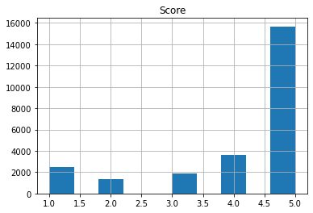

```python
# 평점으로 확인해본 결과 거의 5점임
data_set.hist('Score')
```

```python
# 'Summary'로만 확인해봐도 충분히 나쁜 리뷰가 쓰여있음
data_set[data_set['Score']==1]['Summary']
```

```
25014    raspebrry chocolate chocolate raspberry
25015                  least favorite k cup date
25025                   incredibly disappointing
25027                                waste money
25030                   happened favorite coffee
                          ...
49908                                plain awful
49909                                      never
49910                                      gross
49911               another organic bar half fat
49977                                 misleading
Name: Summary, Length: 2478, dtype: object
```

```python
data_product=data_set.groupby('ProductId')
```

```
array([[<matplotlib.axes._subplots.AxesSubplot object at 0x000001FA921981F0>]],
      dtype=object)
```

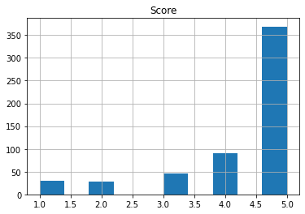

```python
data_set[data_set['ProductId']=='B007M83302'].hist('Score')
```

```
array([[<matplotlib.axes._subplots.AxesSubplot object at 0x000001FA92223AC0>]],
      dtype=object)
```

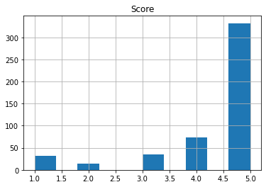

```python
data_set[data_set['ProductId']=='B000PDY3P0'].hist('Score')
```

```
array([[<matplotlib.axes._subplots.AxesSubplot object at 0x000001FA92297340>]],
      dtype=object)
```

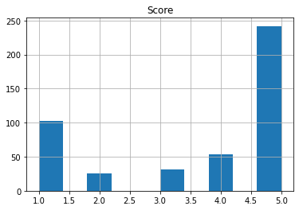

```python
data_set[data_set['ProductId']=='B004SRH2B6'].hist('Score')
```

```
array([[<matplotlib.axes._subplots.AxesSubplot object at 0x000001FA92311FD0>]],
      dtype=object)
```

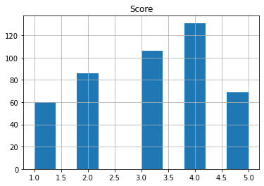

```python
data_set[data_set['ProductId']=='B0041NYV8E'].hist('Score')
```

```python
data_set[data_set['ProductId']=='B0041NYV8E']
```

|  | Id | ProductId | UserId | HelpfulnessNumerator | HelpfulnessDenominator | Score | Time | Summary | Text | Helpfulness |
| --- | --- | --- | --- | --- | --- | --- | --- | --- | --- | --- |
| 45502 | 45503 | B0041NYV8E | A22KL4WOK6GTW2 | 0 | 0 | 2 | 1338163200 | ok | I was expecting a lot more from this product. ... | NaN |
| 45503 | 45504 | B0041NYV8E | A3IAU6ZPVF2R5K | 0 | 0 | 1 | 1337990400 | ew | It sounded Good I prepared it according to di... | NaN |
| 45504 | 45505 | B0041NYV8E | A3KDO3XV0MK1GX | 0 | 0 | 3 | 1337817600 | recommended ginger fans | Like most other reviewers have stated, the gin... | NaN |
| 45505 | 45506 | B0041NYV8E | A3DOPYDOS49I3T | 0 | 0 | 4 | 1337212800 | bad | I am not a big ginger guy but this is not that... | NaN |
| 45506 | 45507 | B0041NYV8E | AFFVUZEGP1FDQ | 0 | 0 | 1 | 1337126400 | pretty darn bad | This is pretty much one of the most unpalatabl... | NaN |
| ... | ... | ... | ... | ... | ... | ... | ... | ... | ... | ... |
| 45949 | 45950 | B0041NYV8E | A2TXMYYGSZCSZ1 | 0 | 0 | 2 | 1339718400 | u | I thought this product sounded interesting sin... | NaN |
| 45950 | 45951 | B0041NYV8E | AW2BZYHG2MGSN | 0 | 0 | 1 | 1339545600 | bland taste terrible | The only redeeming quality about this product ... | NaN |
| 45951 | 45952 | B0041NYV8E | A3J356L2ADK05Z | 0 | 0 | 4 | 1339286400 | bit strong good | I'm not familiar with ginger but I like the ta... | NaN |
| 45952 | 45953 | B0041NYV8E | A13K6456TOHEIR | 0 | 0 | 5 | 1338854400 | versatile natural well balanced | Good balance between the honey sweetness and t... | NaN |
| 45953 | 45954 | B0041NYV8E | A1H88L8X6HM1BQ | 0 | 0 | 4 | 1338768000 | good occassional treat | This ginger and lemon powder is mixed with hot... | NaN |

452 rows × 10 columns

리뷰가 많은 제품을 몇 가지 뽑아서 Score을 확인해보다가, Score가 상대적으로 고르게 분포되어있는 제품 발견.  
이 제품의 리뷰를 보았을 때 Score가 높다고 무조건적으로 좋은 리뷰가 아니었고, Score가 낮을 때도 마찬가지.  
리뷰 내에서의 감정분석으로 리뷰를 분석

```python
import seaborn as sns
import matplotlib.pyplot as plt
```

```python
data_set["Helpfulness"]=data_set["HelpfulnessNumerator"]/data_set["HelpfulnessDenominator"]
data_set.corr()
#Score과 Helpfulness 간에 양의 상관관계가 나오는 것 확인 가능
```

|  | Id | HelpfulnessNumerator | HelpfulnessDenominator | Score | Time | Helpfulness |
| --- | --- | --- | --- | --- | --- | --- |
| Id | 1.000000 | 0.004081 | 0.008840 | -0.008529 | 0.023320 | -0.024977 |
| HelpfulnessNumerator | 0.004081 | 1.000000 | 0.963344 | -0.002906 | -0.138119 | 0.140836 |
| HelpfulnessDenominator | 0.008840 | 0.963344 | 1.000000 | -0.093407 | -0.152027 | 0.001520 |
| Score | -0.008529 | -0.002906 | -0.093407 | 1.000000 | -0.156520 | 0.357513 |
| Time | 0.023320 | -0.138119 | -0.152027 | -0.156520 | 1.000000 | -0.043450 |
| Helpfulness | -0.024977 | 0.140836 | 0.001520 | 0.357513 | -0.043450 | 1.000000 |

원활한 리뷰 감정분석을 위해 대소문자 통일, 표제어 추출 등 문장 전처리

```python
from nltk.corpus import stopwords
```

```python
data_set['Text']
```

```
25000    Van Houtte is my favorite K cups brand. I am r...
25001    I just ordered and received this flavor of K-c...
25002    How can anyone go wrong with Chocolate Raspber...
25003    This is a great smooth flavorful cup of coffee...
25004    This coffee is a great yummy flavor and a favo...
                               ...
49995    My sister introduced me to these. They have be...
49996    A friend recommended these bars and I fell in ...
49997    Fabulous!  I take one to work with me every da...
49998    I love these bars and will continue to buy the...
49999    These are very good; nutritious, great flavor ...
Name: Text, Length: 25000, dtype: object
```

```python
data_set['Text'] = data_set['Text'].apply(lambda x: " ".join(x.lower() for x in x.split()))
data_set['Text'] = data_set['Text'].str.replace('[^\w\s]', "") #???
data_set['Text'].head()
```

```
25000    van houtte is my favorite k cup brand i am rea...
25001    i just ordered and received this flavor of kcu...
25002    how can anyone go wrong with chocolate raspber...
25003    this is a great smooth flavorful cup of coffee...
25004    this coffee is a great yummy flavor and a favo...
Name: Text, dtype: object
```

## textblob - 객체지향 NLP 라이브러리

textblob은 NLTK를 기반으로 하여 텍스트 처리를 수월하게 할 수 있도록 다양한 기능을 많이 포함시킴.  
중복되는 단어를 없애줌  
TextBlob 클래스를 활용하여 감성분석을 수행할 수 있다. TextBlob 어휘사전은 GitHub에서 확인할 수 있다.  
단순히 단어 단위가 아닌, 단어와 단어 사이의 관계까지 파악하여 구 또는 절 단위에서 감정분석이 가능함.

```python
!pip install -U textblob
!python -m textblob.download_corpora
```

```
Finished.
```

```python
from textblob import TextBlob
from textblob import Word
```

```python
from tqdm import tqdm
tqdm.pandas()
data_set['Text'] = data_set['Text'].progress_apply(lambda x: " ".join([Word(word).lemmatize() for word in x.split()]))
#progress_apply로 진행 상황 확인 가능 - tqdm
#lemmatize()로 표제어 추출
data_set['Text']
```

```
25000    van houtte is my favorite k cup brand i am rea...
25001    i just ordered and received this flavor of kcu...
25002    how can anyone go wrong with chocolate raspber...
25003    this is a great smooth flavorful cup of coffee...
25004    this coffee is a great yummy flavor and a favo...
                               ...
49972    great live food bar excellent flavor and dense...
49973    i bought 3 flavor of these bar but i cant tell...
49974    the raw revolution coconut agave bar taste ver...
49975    a local grocer recently had a display of vario...
49976    theyre okay but not the best tasting theyre ju...
Name: Text, Length: 13079, dtype: object
```

정제된 문장으로 sentiment analysis 진행

```python
!pip install vaderSentiment
```

```python
from vaderSentiment.vaderSentiment import SentimentIntensityAnalyzer
analyzer = SentimentIntensityAnalyzer()
```

neg = 부정(negative)  
neu = 중립(neutral)  
pos = 긍정(positive)  
compound = 정규화되고 가중된 종합 점수

```python
listing = []
for row in tqdm(data_set['Text']):
    vs = analyzer.polarity_scores(row)
    listing.append(vs)

df_results = pd.DataFrame(listing)
df_results.head()
```

|  | neg | neu | pos | compound |
| --- | --- | --- | --- | --- |
| 0 | 0.000 | 0.705 | 0.295 | 0.7713 |
| 1 | 0.000 | 0.769 | 0.231 | 0.6597 |
| 2 | 0.145 | 0.701 | 0.154 | 0.0516 |
| 3 | 0.000 | 0.705 | 0.295 | 0.7964 |
| 4 | 0.000 | 0.609 | 0.391 | 0.9493 |

```python
df_with_sent = pd.concat([data_set.reset_index(drop=True), df_results], axis=1)
df_with_sent.head()
```

|  | Id | ProductId | UserId | HelpfulnessNumerator | HelpfulnessDenominator | Score | Time | Summary | Text | Helpfulness | neg | neu | pos | compound |
| --- | --- | --- | --- | --- | --- | --- | --- | --- | --- | --- | --- | --- | --- | --- |
| 0 | 25001 | B0078Y6OX8 | A3P0TJ7GYKM9L9 | 1 | 1 | 5 | 1284681600 | delicious coffee | van houtte is my favorite k cup brand i am rea... | 1.0 | 0.000 | 0.705 | 0.295 | 0.7713 |
| 1 | 25002 | B0078Y6OX8 | A3THT6EZQFPY7P | 1 | 1 | 5 | 1283904000 | love flavor | i just ordered and received this flavor of kcu... | 1.0 | 0.000 | 0.769 | 0.231 | 0.6597 |
| 2 | 25003 | B0078Y6OX8 | A2BUSR3U0RVFAM | 1 | 1 | 4 | 1282953600 | chocolate raspberry truffle k cup | how can anyone go wrong with chocolate raspber... | 1.0 | 0.145 | 0.701 | 0.154 | 0.0516 |
| 3 | 25004 | B0078Y6OX8 | A2Z4TQN4C4WSSB | 1 | 1 | 5 | 1282348800 | wonderful flavor | this is a great smooth flavorful cup of coffee... | 1.0 | 0.000 | 0.705 | 0.295 | 0.7964 |
| 4 | 25005 | B0078Y6OX8 | A2Z4TQN4C4WSSB | 1 | 1 | 5 | 1282348800 | yummy flavor | this coffee is a great yummy flavor and a favo... | 1.0 | 0.000 | 0.609 | 0.391 | 0.9493 |

```python
df_with_sent['Sentiment'] = np.where(df_results['compound']>=0, 'Positive', 'Negative')
```

```python
df_with_sent.head()
```

|  | Id | ProductId | UserId | HelpfulnessNumerator | HelpfulnessDenominator | Score | Time | Summary | Text | Helpfulness | neg | neu | pos | compound | Sentiment |
| --- | --- | --- | --- | --- | --- | --- | --- | --- | --- | --- | --- | --- | --- | --- | --- |
| 0 | 25001 | B0078Y6OX8 | A3P0TJ7GYKM9L9 | 1 | 1 | 5 | 1284681600 | delicious coffee | van houtte is my favorite k cup brand i am rea... | 1.0 | 0.000 | 0.705 | 0.295 | 0.7713 | Positive |
| 1 | 25002 | B0078Y6OX8 | A3THT6EZQFPY7P | 1 | 1 | 5 | 1283904000 | love flavor | i just ordered and received this flavor of kcu... | 1.0 | 0.000 | 0.769 | 0.231 | 0.6597 | Positive |
| 2 | 25003 | B0078Y6OX8 | A2BUSR3U0RVFAM | 1 | 1 | 4 | 1282953600 | chocolate raspberry truffle k cup | how can anyone go wrong with chocolate raspber... | 1.0 | 0.145 | 0.701 | 0.154 | 0.0516 | Positive |
| 3 | 25004 | B0078Y6OX8 | A2Z4TQN4C4WSSB | 1 | 1 | 5 | 1282348800 | wonderful flavor | this is a great smooth flavorful cup of coffee... | 1.0 | 0.000 | 0.705 | 0.295 | 0.7964 | Positive |
| 4 | 25005 | B0078Y6OX8 | A2Z4TQN4C4WSSB | 1 | 1 | 5 | 1282348800 | yummy flavor | this coffee is a great yummy flavor and a favo... | 1.0 | 0.000 | 0.609 | 0.391 | 0.9493 | Positive |

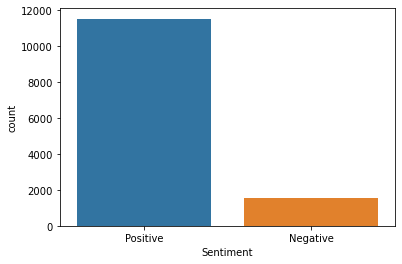

```python
sns.countplot(df_with_sent['Sentiment'])
plt.show()
```

```python
df_with_sent.groupby('ProductId')['Sentiment'].value_counts()
```

```
ProductId   Sentiment
B00008DF91  Positive     5
B00008DFR5  Positive     3
B00008MOJ2  Positive     2
B0000A0BS8  Positive     2
B0000AH3QT  Positive     2
                        ..
B0096RP84Q  Positive     2
B009DR3GYI  Positive     3
B009GUDRDM  Positive     2
B009KAQZ9G  Positive     2
B009NTCO4O  Positive     8
Name: Sentiment, Length: 2595, dtype: int64
```

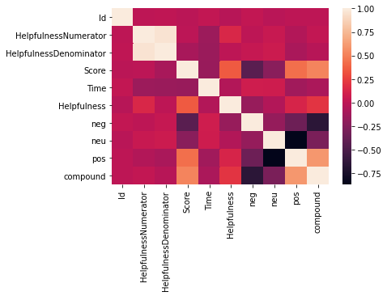

```python
sns.heatmap(df_with_sent.corr())
#score과 compound가 0.5정도의 상관관계가 보임을 확인
```